# Piece 2

Benjamin Egan

2025-02-06

## Tragectories and Variations of Family Decision Making Across Countires

In this piece, I will demonstrate my graphing abilities.

### Data Being Used

Several different variables were used for the following analyses. Alongside Family Decision Making (FDM), Age (Age), Socio-economic Status (SES), Gender (ChGender), and Country of origin (Country) were used to help identify potential trends in the data. Below are the countries utilized in this dataset.

```r
levels(data$Country)
```

```
##  [1] "USA-Hispanic"          "China-Jinan"           "China-Shanghai"
##  [4] "Italy-Naples"          "Italy-Rome"            "Kenya"
##  [7] "Philippines"           "Thailand"              "Sweden"
## [10] "USA-African American"  "USA-European American" "Colombia"
## [13] "Jordan"                "China-Chongqing"
```

## Plotting Family Decision Making

I can begin by making a plot of Age and Family Decision Making.

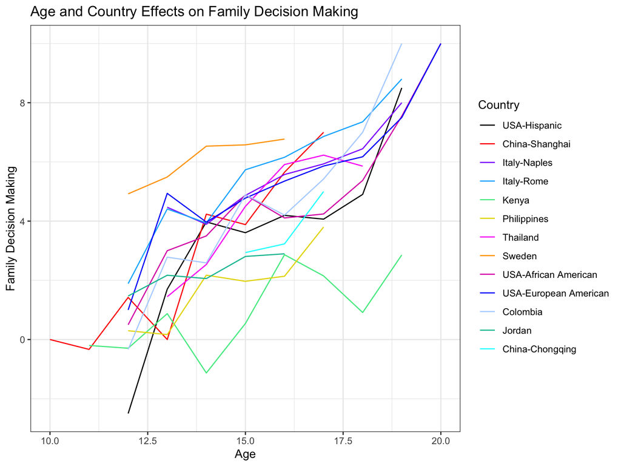

```r
data %>%
ggplot(
  aes(x=Age_Exact,
      y = FDM,
      group = Country,
      color = Country)) +
  geom_line(stat = "summary", fun = "mean") +
  theme_bw() +
  scale_color_manual(values=c("#000000","#ff0000","#8F00FF", "#0bb4ff", "#50e991", "#e6d800", "#fb19f5", "#ffa300", "#dc0ab4", "#0000fB", "#b3d4ff", "#00bfa0", "#00ffff")) +
  labs(
    x = "Age",
    y = "Family Decision Making",
    color = "Country",
    title = "Age and Country Effects on Family Decision Making")
```

This plot is ok, but there are majors ways to improve it. There is no rhyme or reason to the colors included, and it’s hard to visualize the trend of “Family Decision Making increases as adolescents increase in age.”

My first suggestion is to smooth out the lines.

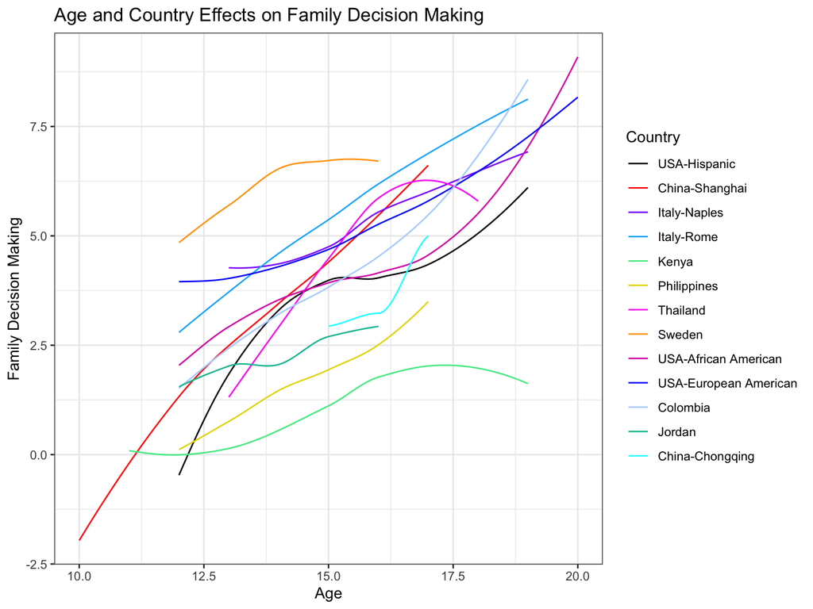

```r
data %>%
ggplot(
  aes(x=Age_Exact,
      y = FDM,
      group = Country,
      color = Country)) +
  geom_smooth(
    size = .5,
    span = 1,
    se = FALSE) +
  theme_bw() +
  scale_color_manual(values=c("#000000","#ff0000","#8F00FF", "#0bb4ff", "#50e991", "#e6d800", "#fb19f5", "#ffa300", "#dc0ab4", "#0000fB", "#b3d4ff", "#00bfa0", "#00ffff")) +
  labs(
    x = "Age",
    y = "Family Decision Making",
    color = "Country",
    title = "Age and Country Effects on Family Decision Making")
```

This had the effect of minimizing the noise of the first graph. It is easier to see the overall positive linear trend of Family Decision Making as adolescents get older.

The next suggestion is to combine some of the data. For example, we can combine the United states ethnicities to create one USA line.

```r
Country_Collapse <- data %>%
  mutate(Country = case_when(
    Country %in% c("USA-African American", "USA-European American", "USA-Hispanic") ~ "United States",
    Country %in% c("China-Shanghai", "China-Chongqing") ~ "China",
    Country %in% c("Italy-Naples", "Italy-Rome") ~ "Italy",
    Country == "Kenya" ~ "Kenya",
    Country == "Philippines" ~ "Philippines",
    Country == "Thailand" ~ "Thailand",
    Country == "Sweden" ~ "Sweden",
    Country == "Colombia" ~ "Colombia",
    Country == "Jordan" ~ "Jordan",
    Country == "India" ~ "India"
  ))
```

Now we can create a plot that just reflects countries.

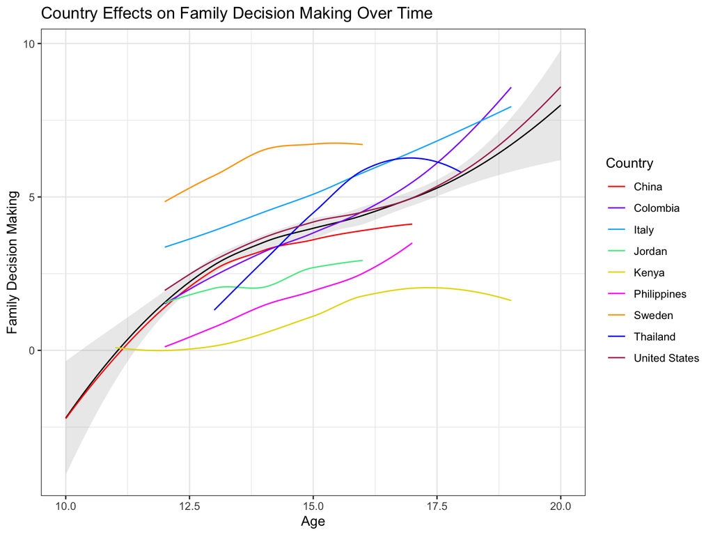

```r
Country_Collapse %>%
ggplot(
  aes(x=Age_Exact,
      y = FDM,
      group = Country,
      color = Country)) +
  geom_smooth(
    aes(group = 1),
    method = "loess",
    formula = y~x,
    se = TRUE,
    alpha = .2,
    color = "black",
    size = .5
  ) +
  geom_smooth(
    size = .5,
    span = 1,
    se = FALSE
    ) +
  theme_bw() +
  scale_color_manual(values=c("#ff0000","#8F00FF", "#0bb4ff", "#50e991", "#e6d800", "#fb19f5", "#ffa300", "#0000fB", "maroon", "#00bfa0")) +
  labs(
    x = "Age",
    y = "Family Decision Making",
    color = "Country",
    title = "Country Effects on Family Decision Making Over Time")
```

```r
  scale_fill_brewer(palette = "Set1")
```

[output not shown]

```r
#change to geom_smooth, collapse country data (ex, all US data), change colors to represent continents, change title to better reflect data, look at doing a spaghetti plot (each person put on a graph).
```

This helped clean up some of the clutter of the extra lines. I also included the average FDM line to help show the distinct differences across countries.

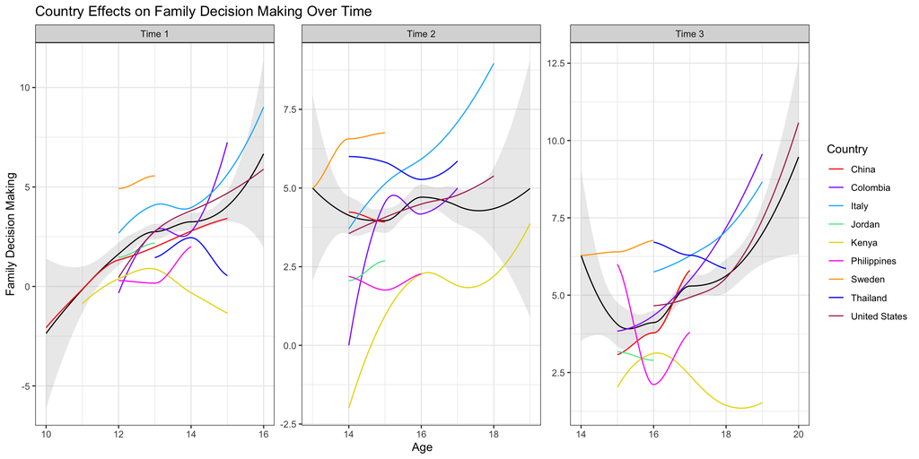

```r
Country_Collapse <- Country_Collapse %>%
  mutate(Index1 = case_when(
    Index1 == "1" ~ "Time 1",
    Index1 == "2" ~ "Time 2",
    Index1 == "3" ~ "Time 3"
  ))
view(Country_Collapse)

Country_Collapse %>% ggplot(
  aes(x=Age_Exact,
      y = FDM,
      group = Country,
      color = Country)) +
  geom_smooth(
    aes(group = 1),
    method = "loess",
    formula = y~x,
    se = TRUE,
    alpha = .2,
    color = "black",
    size = .5
  ) +
  facet_wrap(~Index1, scales = "free") +
  geom_smooth(
    size = .5,
    span = 1,
    se = FALSE
    ) +
  theme_bw() +
  scale_color_manual(values=c("#ff0000","#8F00FF", "#0bb4ff", "#50e991", "#e6d800", "#fb19f5", "#ffa300", "#0000fB", "maroon", "#00bfa0")) +
  labs(
    x = "Age",
    y = "Family Decision Making",
    color = "Country",
    title = "Country Effects on Family Decision Making Over Time")
```

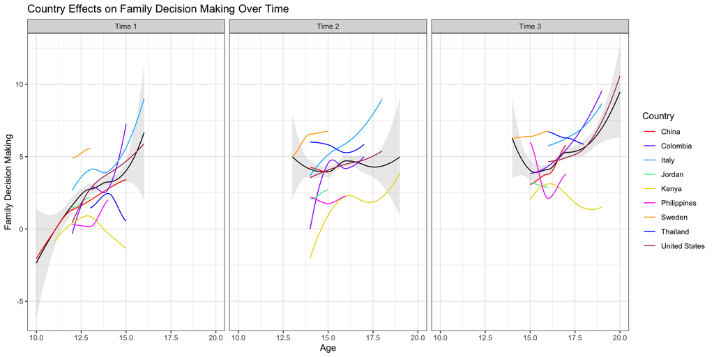